# Assignment 2 (Session 7, 8 & 9)

### Select

```r
select(flights,year,month:day)    #Column between month and day
```

```
## # A tibble: 336,776 × 3
##     year month   day
##    <int> <int> <int>
##  1  2013     1     1
##  2  2013     1     1
##  3  2013     1     1
##  4  2013     1     1
##  5  2013     1     1
##  6  2013     1     1
##  7  2013     1     1
##  8  2013     1     1
##  9  2013     1     1
## 10  2013     1     1
## # ℹ 336,766 more rows
```

```r
select(flights,-(year:day))     #Exclude column between year and day
```

```
## # A tibble: 336,776 × 16
##    dep_time sched_dep_time dep_delay arr_time sched_arr_time arr_delay carrier
##       <int>          <int>     <dbl>    <int>          <int>     <dbl> <chr>
##  1      517            515         2      830            819        11 UA
##  2      533            529         4      850            830        20 UA
##  3      542            540         2      923            850        33 AA
##  4      544            545        -1     1004           1022       -18 B6
##  5      554            600        -6      812            837       -25 DL
##  6      554            558        -4      740            728        12 UA
##  7      555            600        -5      913            854        19 B6
##  8      557            600        -3      709            723       -14 EV
##  9      557            600        -3      838            846        -8 B6
## 10      558            600        -2      753            745         8 AA
## # ℹ 336,766 more rows
## # ℹ 9 more variables: flight <int>, tailnum <chr>, origin <chr>, dest <chr>,
## #   air_time <dbl>, distance <dbl>, hour <dbl>, minute <dbl>, time_hour <dttm>
```

```r
select(flights,time_hour,air_time)
```

```
## # A tibble: 336,776 × 2
##    time_hour           air_time
##    <dttm>                 <dbl>
##  1 2013-01-01 05:00:00      227
##  2 2013-01-01 05:00:00      227
##  3 2013-01-01 05:00:00      160
##  4 2013-01-01 05:00:00      183
##  5 2013-01-01 06:00:00      116
##  6 2013-01-01 05:00:00      150
##  7 2013-01-01 06:00:00      158
##  8 2013-01-01 06:00:00       53
##  9 2013-01-01 06:00:00      140
## 10 2013-01-01 06:00:00      138
## # ℹ 336,766 more rows
```

### Mutate

Adds new column to existing column  
Mutate gain,speed,hours and gain_per_hour column in existing.

```r
flights_sml<-select(flights,
                    year:day,
                    ends_with("delay"),
                    distance,
                    air_time
)
flights_sml
```

```
## # A tibble: 336,776 × 7
##     year month   day dep_delay arr_delay distance air_time
##    <int> <int> <int>     <dbl>     <dbl>    <dbl>    <dbl>
##  1  2013     1     1         2        11     1400      227
##  2  2013     1     1         4        20     1416      227
##  3  2013     1     1         2        33     1089      160
##  4  2013     1     1        -1       -18     1576      183
##  5  2013     1     1        -6       -25      762      116
##  6  2013     1     1        -4        12      719      150
##  7  2013     1     1        -5        19     1065      158
##  8  2013     1     1        -3       -14      229       53
##  9  2013     1     1        -3        -8      944      140
## 10  2013     1     1        -2         8      733      138
## # ℹ 336,766 more rows
```

```r
mutate(flights_sml,
       gain=dep_delay - arr_delay,
       speed= distance / air_time * 60,
       hours = air_time /60,
       gain_per_hour = gain /hours
)
```

```
## # A tibble: 336,776 × 11
##     year month   day dep_delay arr_delay distance air_time  gain speed hours
##    <int> <int> <int>     <dbl>     <dbl>    <dbl>    <dbl> <dbl> <dbl> <dbl>
##  1  2013     1     1         2        11     1400      227    -9  370. 3.78
##  2  2013     1     1         4        20     1416      227   -16  374. 3.78
##  3  2013     1     1         2        33     1089      160   -31  408. 2.67
##  4  2013     1     1        -1       -18     1576      183    17  517. 3.05
##  5  2013     1     1        -6       -25      762      116    19  394. 1.93
##  6  2013     1     1        -4        12      719      150   -16  288. 2.5
##  7  2013     1     1        -5        19     1065      158   -24  404. 2.63
##  8  2013     1     1        -3       -14      229       53    11  259. 0.883
##  9  2013     1     1        -3        -8      944      140     5  405. 2.33
## 10  2013     1     1        -2         8      733      138   -10  319. 2.3
## # ℹ 336,766 more rows
## # ℹ 1 more variable: gain_per_hour <dbl>
```

### Transmute

It is used only to keep the new variables

```r
transmute(flights,
          gain=dep_delay - arr_delay,
          hours = air_time/60,
          gain_per_hour=gain/hours,
)
```

```
## # A tibble: 336,776 × 3
##     gain hours gain_per_hour
##    <dbl> <dbl>         <dbl>
##  1    -9 3.78          -2.38
##  2   -16 3.78          -4.23
##  3   -31 2.67         -11.6
##  4    17 3.05           5.57
##  5    19 1.93           9.83
##  6   -16 2.5           -6.4
##  7   -24 2.63          -9.11
##  8    11 0.883         12.5
##  9     5 2.33           2.14
## 10   -10 2.3           -4.35
## # ℹ 336,766 more rows
```

```r
transmute(flights,
          dep_time,
          hour =dep_time %/% 100,      #Modular
          minute =dep_time %% 100,     #Remainder
)
```

```
## # A tibble: 336,776 × 3
##    dep_time  hour minute
##       <int> <dbl>  <dbl>
##  1      517     5     17
##  2      533     5     33
##  3      542     5     42
##  4      544     5     44
##  5      554     5     54
##  6      554     5     54
##  7      555     5     55
##  8      557     5     57
##  9      557     5     57
## 10      558     5     58
## # ℹ 336,766 more rows
```

### Summarise

To group the variable by value

```r
summarise(flights,delay=mean(dep_delay,na.rm=TRUE))
```

```
## # A tibble: 1 × 1
##   delay
##   <dbl>
## 1  12.6
```

```r
by_day<-group_by(flights,year,month,day)
summarise(by_day,delay=mean(dep_delay,na.rm=TRUE), .groups = 'drop')
```

```
## # A tibble: 365 × 4
##     year month   day delay
##    <int> <int> <int> <dbl>
##  1  2013     1     1 11.5
##  2  2013     1     2 13.9
##  3  2013     1     3 11.0
##  4  2013     1     4  8.95
##  5  2013     1     5  5.73
##  6  2013     1     6  7.15
##  7  2013     1     7  5.42
##  8  2013     1     8  2.55
##  9  2013     1     9  2.28
## 10  2013     1    10  2.84
## # ℹ 355 more rows
```

## MULTIPLE OPERATION WITH PIPES

Displays the mean distance of flights and mean arrival delay of flights to each destination with more than 20 flights excluding destination “HNL”

```r
delays<-flights %>%
  group_by(dest) %>%
  summarise(
    count=n(),
    dist=mean(distance,na.rm = TRUE),
    delay = mean(arr_delay,na.rm = TRUE),
  ) %>%
  filter(count>20,dest != "HNL")
delays
```

```
## # A tibble: 96 × 4
##    dest  count  dist delay
##    <chr> <int> <dbl> <dbl>
##  1 ABQ     254 1826   4.38
##  2 ACK     265  199   4.85
##  3 ALB     439  143  14.4
##  4 ATL   17215  757. 11.3
##  5 AUS    2439 1514.  6.02
##  6 AVL     275  584.  8.00
##  7 BDL     443  116   7.05
##  8 BGR     375  378   8.03
##  9 BHM     297  866. 16.9
## 10 BNA    6333  758. 11.8
## # ℹ 86 more rows
```

Remove Cancelled flights First, Filters only those rows where departure delay and arrival delay is not missing which means the flight has take-off and landed.

```r
not_cancelled<- flights %>%
  filter(!is.na(dep_delay),!is.na(arr_delay))
not_cancelled
```

```
## # A tibble: 327,346 × 19
##     year month   day dep_time sched_dep_time dep_delay arr_time sched_arr_time
##    <int> <int> <int>    <int>          <int>     <dbl>    <int>          <int>
##  1  2013     1     1      517            515         2      830            819
##  2  2013     1     1      533            529         4      850            830
##  3  2013     1     1      542            540         2      923            850
##  4  2013     1     1      544            545        -1     1004           1022
##  5  2013     1     1      554            600        -6      812            837
##  6  2013     1     1      554            558        -4      740            728
##  7  2013     1     1      555            600        -5      913            854
##  8  2013     1     1      557            600        -3      709            723
##  9  2013     1     1      557            600        -3      838            846
## 10  2013     1     1      558            600        -2      753            745
## # ℹ 327,336 more rows
## # ℹ 11 more variables: arr_delay <dbl>, carrier <chr>, flight <int>,
## #   tailnum <chr>, origin <chr>, dest <chr>, air_time <dbl>, distance <dbl>,
## #   hour <dbl>, minute <dbl>, time_hour <dttm>
```

Secondly, Calculate the mean departure delay for each day.

```r
not_cancelled %>%
  group_by(year,month,day) %>%
  summarise(mean=mean(dep_delay), .groups = 'drop')
```

```
## # A tibble: 365 × 4
##     year month   day  mean
##    <int> <int> <int> <dbl>
##  1  2013     1     1 11.4
##  2  2013     1     2 13.7
##  3  2013     1     3 10.9
##  4  2013     1     4  8.97
##  5  2013     1     5  5.73
##  6  2013     1     6  7.15
##  7  2013     1     7  5.42
##  8  2013     1     8  2.56
##  9  2013     1     9  2.30
## 10  2013     1    10  2.84
## # ℹ 355 more rows
```

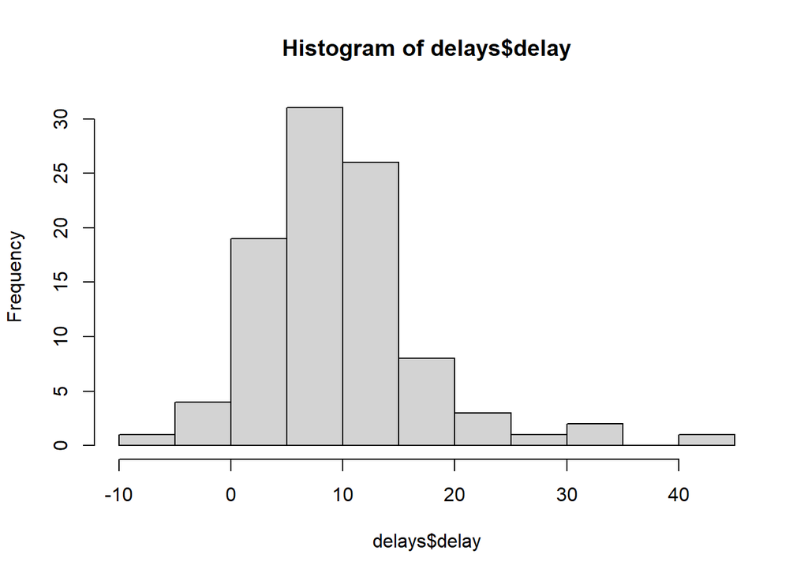

```r
  hist(delays$delay)
```

## Summary Function

1. When do the first and last flights leave each day?  
   Calculate the minimum departure time and maximum departure time every day using min and max value of departure time

```r
not_cancelled %>%
  group_by(year,month,day) %>%
  summarise(
    first= min(dep_time),
    last = max(dep_time), .groups = 'drop'
  )
```

```
## # A tibble: 365 × 5
##     year month   day first  last
##    <int> <int> <int> <int> <int>
##  1  2013     1     1   517  2356
##  2  2013     1     2    42  2354
##  3  2013     1     3    32  2349
##  4  2013     1     4    25  2358
##  5  2013     1     5    14  2357
##  6  2013     1     6    16  2355
##  7  2013     1     7    49  2359
##  8  2013     1     8   454  2351
##  9  2013     1     9     2  2252
## 10  2013     1    10     3  2320
## # ℹ 355 more rows
```

On Jan 1 first departure time is 5:17 AM and last departure time is 11:56 PM.

2. Why is distance to some destinations more variable than to others?  
   Calculates the mean distance and standard deviation distance(in descending order)

```r
not_cancelled %>%
  group_by(dest) %>%
  summarise(
    distance_mean=mean(distance),distance_sd=sd(distance)) %>%
  arrange(desc(distance_sd))
```

```
## # A tibble: 104 × 3
##    dest  distance_mean distance_sd
##    <chr>         <dbl>       <dbl>
##  1 EGE           1736.       10.5
##  2 SAN           2437.       10.4
##  3 SFO           2578.       10.2
##  4 HNL           4973.       10.0
##  5 SEA           2413.        9.98
##  6 LAS           2241.        9.91
##  7 PDX           2446.        9.87
##  8 PHX           2141.        9.86
##  9 LAX           2469.        9.66
## 10 IND            652.        9.46
## # ℹ 94 more rows
```

3. Which destination have the most carries?

```r
not_cancelled %>%
  group_by(dest) %>%
  summarise(carriers=n_distinct(carrier)) %>%
  arrange(desc(carriers))
```

```
## # A tibble: 104 × 2
##    dest  carriers
##    <chr>    <int>
##  1 ATL          7
##  2 BOS          7
##  3 CLT          7
##  4 ORD          7
##  5 TPA          7
##  6 AUS          6
##  7 DCA          6
##  8 DTW          6
##  9 IAD          6
## 10 MSP          6
## # ℹ 94 more rows
```

“ATL”,“BOS”,“CLT”,“ORD”,“TPA” has the most carries

4. How many flights left before 5am daily?  
   Shows the number of flights departing earlier than 5:00 AM everyday

```r
not_cancelled %>%
  group_by(year,month,day) %>%
  summarise(n_early=sum(dep_time<500), .groups = 'drop')
```

```
## # A tibble: 365 × 4
##     year month   day n_early
##    <int> <int> <int>   <int>
##  1  2013     1     1       0
##  2  2013     1     2       3
##  3  2013     1     3       4
##  4  2013     1     4       3
##  5  2013     1     5       3
##  6  2013     1     6       2
##  7  2013     1     7       2
##  8  2013     1     8       1
##  9  2013     1     9       3
## 10  2013     1    10       3
## # ℹ 355 more rows
```

On Jan 1 no flight has departed earlier than 5:00 AM

5. what proportion of flight are delayed by more than an hour?

```r
not_cancelled %>%
  group_by(year,month,day) %>%
  summarise(hour_prop=mean(arr_delay>60),.groups = 'drop')
```

```
## # A tibble: 365 × 4
##     year month   day hour_prop
##    <int> <int> <int>     <dbl>
##  1  2013     1     1    0.0722
##  2  2013     1     2    0.0851
##  3  2013     1     3    0.0567
##  4  2013     1     4    0.0396
##  5  2013     1     5    0.0349
##  6  2013     1     6    0.0470
##  7  2013     1     7    0.0333
##  8  2013     1     8    0.0213
##  9  2013     1     9    0.0202
## 10  2013     1    10    0.0183
## # ℹ 355 more rows
```

6. Find all groups bigger than a threshold?  
   Display all the flights only to the destination that have more than flights in total.

```r
popular_dests<- flights %>%
  group_by(dest) %>%
  filter(n()>365)
popular_dests
```

```
## # A tibble: 332,577 × 19
## # Groups:   dest [77]
##     year month   day dep_time sched_dep_time dep_delay arr_time sched_arr_time
##    <int> <int> <int>    <int>          <int>     <dbl>    <int>          <int>
##  1  2013     1     1      517            515         2      830            819
##  2  2013     1     1      533            529         4      850            830
##  3  2013     1     1      542            540         2      923            850
##  4  2013     1     1      544            545        -1     1004           1022
##  5  2013     1     1      554            600        -6      812            837
##  6  2013     1     1      554            558        -4      740            728
##  7  2013     1     1      555            600        -5      913            854
##  8  2013     1     1      557            600        -3      709            723
##  9  2013     1     1      557            600        -3      838            846
## 10  2013     1     1      558            600        -2      753            745
## # ℹ 332,567 more rows
## # ℹ 11 more variables: arr_delay <dbl>, carrier <chr>, flight <int>,
## #   tailnum <chr>, origin <chr>, dest <chr>, air_time <dbl>, distance <dbl>,
## #   hour <dbl>, minute <dbl>, time_hour <dttm>
```

7. Popular destination Group By destination and get the total flights and arrange in descending order.

```r
popular_destination <- flights %>%
  group_by(dest) %>%
  summarise(total_flights = n()) %>%
  filter(total_flights > 365) %>%
  arrange(desc(total_flights))
head(popular_destination$dest)
```

```
## [1] "ORD" "ATL" "LAX" "BOS" "MCO" "CLT"
```

“ORD” is the popular destination

### Slice function

```r
flights %>% slice_sample(n=5,replace = TRUE)
```

```
## # A tibble: 5 × 19
##    year month   day dep_time sched_dep_time dep_delay arr_time sched_arr_time
##   <int> <int> <int>    <int>          <int>     <dbl>    <int>          <int>
## 1  2013     2     3     1518           1455        23     1703           1654
## 2  2013    10    18     1213           1220        -7     1351           1355
## 3  2013     3    20     1131           1135        -4     1446           1447
## 4  2013    10    19      711            630        41     1030            925
## 5  2013     5    26     1734           1725         9     2051           2040
## # ℹ 11 more variables: arr_delay <dbl>, carrier <chr>, flight <int>,
## #   tailnum <chr>, origin <chr>, dest <chr>, air_time <dbl>, distance <dbl>,
## #   hour <dbl>, minute <dbl>, time_hour <dttm>
```

```r
set.seed(123)
train_data <- flights %>% slice_sample(prop = 0.8)
train_data
```

```
## # A tibble: 269,420 × 19
##     year month   day dep_time sched_dep_time dep_delay arr_time sched_arr_time
##    <int> <int> <int>    <int>          <int>     <dbl>    <int>          <int>
##  1  2013     4    26      730            655        35      901            820
##  2  2013     2    26     1714           1720        -6     2031           2040
##  3  2013     2    15     1442           1445        -3     1634           1647
##  4  2013     3    27     1444           1445        -1     1556           1604
##  5  2013     6     5     1428           1430        -2     1537           1555
##  6  2013     2    16      613            600        13      731            735
##  7  2013     5     1      848            850        -2      947           1014
##  8  2013    10    20     1918           1855        23     2132           2130
##  9  2013    11    11      825            835       -10      942           1000
## 10  2013     8    31      656            700        -4      904            929
## # ℹ 269,410 more rows
## # ℹ 11 more variables: arr_delay <dbl>, carrier <chr>, flight <int>,
## #   tailnum <chr>, origin <chr>, dest <chr>, air_time <dbl>, distance <dbl>,
## #   hour <dbl>, minute <dbl>, time_hour <dttm>
```

```r
test_data <- flights %>% slice_sample(prop = 0.2)
test_data
```

```
## # A tibble: 67,355 × 19
##     year month   day dep_time sched_dep_time dep_delay arr_time sched_arr_time
##    <int> <int> <int>    <int>          <int>     <dbl>    <int>          <int>
##  1  2013     8    23     1605           1559         6     1700           1721
##  2  2013     5     2     1222           1205        17     1444           1425
##  3  2013     4     7     1957           2000        -3     2204           2208
##  4  2013     4    16      639            640        -1      837            851
##  5  2013     4     2     1132           1135        -3     1311           1255
##  6  2013     8     7     1006            959         7     1116           1114
##  7  2013     9    26     1826           1829        -3     2014           2033
##  8  2013     5    19     1945           1925        20     2252           2250
##  9  2013     7    15     1654           1659        -5     1843           1905
## 10  2013     4    13      741            745        -4      959           1012
## # ℹ 67,345 more rows
## # ℹ 11 more variables: arr_delay <dbl>, carrier <chr>, flight <int>,
## #   tailnum <chr>, origin <chr>, dest <chr>, air_time <dbl>, distance <dbl>,
## #   hour <dbl>, minute <dbl>, time_hour <dttm>
```